# Introducing R

In this notebook, we’ll introduce some of the fundamental concepts of the R programming language, preparing us for the usage of humdrumR itself. You might also be interested in our “[R primer](https://computational-cognitive-musicology-lab.github.io/humdrumR/articles/RPrimer.html)”, on the humdrumR website.

Open this notebook in Rstudio. Throughout the notebook there are “code blocks”, marked off with backticks and `{r}`. You can run these code blocks by clicking the green arrow at the right side of the window. You can also manipulate or add to the blocks, then click the arrow again!

# Basics

The basics of R syntax are similar to many other programming languages.

We can do arithmetic

```r
4 + 5
```

```
## [1] 9
```

```r
100 * -3
```

```
## [1] -300
```

```r
2^8 # exponents
```

```
## [1] 256
```

```r
# These comments are ignored
```

and “call” functions with zero or more “arguments” inside of parentheses:

```r
Sys.time()
```

```
## [1] "2023-05-04 14:57:47 EDT"
```

```r
sqrt(2)
```

```
## [1] 1.414214
```

```r
log(8, base = 2)
```

```
## [1] 3
```

In R, we can also use functions in “pipes,” which often saves typing. The R pipe looks like `|>`, and you still need those parentheses!

```r
2 |> sqrt()
```

```
## [1] 1.414214
```

```r
16 |> log(base = 2) |> sqrt()
```

```
## [1] 2
```

## Assignment

Like other programming languages, we can give things names by “assigning” them to a variable. In R, we have leftward `<-` and rightward `->` assignment; rightward assignment is useful with pipes!

```r
x <- 4

2^x
```

```
## [1] 16
```

```r
16 |> log(base = 2) -> y

2^(x + y)
```

```
## [1] 256
```

## Vectors

There are three types of basic, “atomic” data we work with in R:

```r
# Numbers:

145
```

```
## [1] 145
```

```r
3.2
```

```
## [1] 3.2
```

```r
2.2e6 # scientific notaion, e6 -> * 10^6
```

```
## [1] 2200000
```

```r
# Character strings:

"C Major"
```

```
## [1] "C Major"
```

```r
"X"
```

```
## [1] "X"
```

```r
"" # empty string
```

```
## [1] ""
```

```r
# Logical values

TRUE
```

```
## [1] TRUE
```

```r
FALSE
```

```
## [1] FALSE
```

```r
NA # invalid data
```

```
## [1] NA
```

```r
NULL # empty, no data
```

However, the best part of R is that these basic data types (except `NULL`) are *always* vectors: ordered collections. The value `3.2` is simply a vector of one number, etc.

We can make vectors directly using the the `c()` function:

```r
c(3, 2, 1.6)
```

```
## [1] 3.0 2.0 1.6
```

```r
c('I', 'IV', 'V', 'I')
```

```
## [1] "I"  "IV" "V"  "I"
```

```r
c(TRUE, FALSE, TRUE)
```

```
## [1]  TRUE FALSE  TRUE
```

We often create sequences of numbers using `:` or the `seq()` function:

```r
1:100
```

```
##   [1]   1   2   3   4   5   6   7   8   9  10  11  12  13  14  15  16  17  18
##  [19]  19  20  21  22  23  24  25  26  27  28  29  30  31  32  33  34  35  36
##  [37]  37  38  39  40  41  42  43  44  45  46  47  48  49  50  51  52  53  54
##  [55]  55  56  57  58  59  60  61  62  63  64  65  66  67  68  69  70  71  72
##  [73]  73  74  75  76  77  78  79  80  81  82  83  84  85  86  87  88  89  90
##  [91]  91  92  93  94  95  96  97  98  99 100
```

```r
seq(0, 1, by = .01)
```

```
##   [1] 0.00 0.01 0.02 0.03 0.04 0.05 0.06 0.07 0.08 0.09 0.10 0.11 0.12 0.13 0.14
##  [16] 0.15 0.16 0.17 0.18 0.19 0.20 0.21 0.22 0.23 0.24 0.25 0.26 0.27 0.28 0.29
##  [31] 0.30 0.31 0.32 0.33 0.34 0.35 0.36 0.37 0.38 0.39 0.40 0.41 0.42 0.43 0.44
##  [46] 0.45 0.46 0.47 0.48 0.49 0.50 0.51 0.52 0.53 0.54 0.55 0.56 0.57 0.58 0.59
##  [61] 0.60 0.61 0.62 0.63 0.64 0.65 0.66 0.67 0.68 0.69 0.70 0.71 0.72 0.73 0.74
##  [76] 0.75 0.76 0.77 0.78 0.79 0.80 0.81 0.82 0.83 0.84 0.85 0.86 0.87 0.88 0.89
##  [91] 0.90 0.91 0.92 0.93 0.94 0.95 0.96 0.97 0.98 0.99 1.00
```

Many R operations/functions are “vectorized,” meaning that they take in vectors and output vectors that are the same length. The key of R’s vectorization is that we, as programmers, don’t need to worry about each element of the vector. We can treat a vector like a single object, and R will oblige. For example, we can do math like:

```r
2^(0:10) - 1
```

```
##  [1]    0    1    3    7   15   31   63  127  255  511 1023
```

```r
(1:10) - (10:1)
```

```
##  [1] -9 -7 -5 -3 -1  1  3  5  7  9
```

```r
sqrt(c(5, 10, 16))
```

```
## [1] 2.236068 3.162278 4.000000
```

Or work with strings like:

```r
paste(1:26, letters, sep = ': ')
```

```
##  [1] "1: a"  "2: b"  "3: c"  "4: d"  "5: e"  "6: f"  "7: g"  "8: h"  "9: i"
## [10] "10: j" "11: k" "12: l" "13: m" "14: n" "15: o" "16: p" "17: q" "18: r"
## [19] "19: s" "20: t" "21: u" "22: v" "23: w" "24: x" "25: y" "26: z"
```

```r
paste('Chord', 1:10)
```

```
##  [1] "Chord 1"  "Chord 2"  "Chord 3"  "Chord 4"  "Chord 5"  "Chord 6"
##  [7] "Chord 7"  "Chord 8"  "Chord 9"  "Chord 10"
```

```r
# Regular expressions:
grepl('[aeiou]', letters)
```

```
##  [1]  TRUE FALSE FALSE FALSE  TRUE FALSE FALSE FALSE  TRUE FALSE FALSE FALSE
## [13] FALSE FALSE  TRUE FALSE FALSE FALSE FALSE FALSE  TRUE FALSE FALSE FALSE
## [25] FALSE FALSE
```

Or get logical values:

```r
#
2^(0:10) > 500
```

```
##  [1] FALSE FALSE FALSE FALSE FALSE FALSE FALSE FALSE FALSE  TRUE  TRUE
```

Of course, other R functions take in vectors and return scalar (single) values. Examples:

```r
length(seq(50, 90, by = .2))
```

```
## [1] 201
```

```r
length(letters)
```

```
## [1] 26
```

```r
sum(c(1, 5, 9))
```

```
## [1] 15
```

```r
mean(c(1, 5, 9))
```

```
## [1] 5
```

```r
max(c(1, 5, 9))
```

```
## [1] 9
```

Vectorization works very well when you are working with vectors that are either 1) all the same length or 2) length 1 (scalar). If vectors are different lengths, the shorter one will be “recycled” (repeated) to match the longer one.

```r
c(0, 5) * 1:10
```

```
##  [1]  0 10  0 20  0 30  0 40  0 50
```

### Excercises

> What is the sum of the first 1000 integers (1 to 1000)?

> How many numbers between 1 and 1000 are divisible by 7?

### Indexing

“Indexing” means to select subsets of a vector. We use the `[]` operators, which can be provided numbers or logical values.

```r
letters[1:10]
```

```
##  [1] "a" "b" "c" "d" "e" "f" "g" "h" "i" "j"
```

```r
# get every other letter in the alphabet

# get all numbers between 1:1000 that are divisible by 9
```

Negative numbers can be used to *remove* those indices:

```r
letters[-1]
```

```
##  [1] "b" "c" "d" "e" "f" "g" "h" "i" "j" "k" "l" "m" "n" "o" "p" "q" "r" "s" "t"
## [20] "u" "v" "w" "x" "y" "z"
```

```r
letters[-1:-10]
```

```
##  [1] "k" "l" "m" "n" "o" "p" "q" "r" "s" "t" "u" "v" "w" "x" "y" "z"
```

# Data frames

To work with real data, we’ll want to put our vectors in to “data frames”: collections of vectors that are all the same length.

```r
scale <- data.frame(Letter =  c("C", "D", "E", "F", "G", "A", "B", "C"),
                    PitchClass =c(0, 2, 4, 5, 7, 9, 11, 12),
                    Interval = c("P1", "M2", "M3", "P4", "P5", "M6", "M7", "P8"))
scale
```

| Letter | PitchClass | Interval |
| --- | --- | --- |
| C | 0 | P1 |
| D | 2 | M2 |
| E | 4 | M3 |
| F | 5 | P4 |
| G | 7 | P5 |
| A | 9 | M6 |
| B | 11 | M7 |
| C | 12 | P8 |

Notice that we gave each vector a name *inside* the data frame. We can access each column using `$`:

```r
scale$Letter
```

```
## [1] "C" "D" "E" "F" "G" "A" "B" "C"
```

We can add to the data frame by assigning to that same `$`:

```r
scale$Tonic <- scale$Letter == 'C'
scale
```

| Letter | PitchClass | Interval | Tonic |
| --- | --- | --- | --- |
| C | 0 | P1 | TRUE |
| D | 2 | M2 | FALSE |
| E | 4 | M3 | FALSE |
| F | 5 | P4 | FALSE |
| G | 7 | P5 | FALSE |
| A | 9 | M6 | FALSE |
| B | 11 | M7 | FALSE |
| C | 12 | P8 | TRUE |

We can index data frames using `[i, j]`, where `i` indexes rows and `j` indexes columns:

```r
scale[1:5, ]
```

|  | Letter | PitchClass | Interval | Tonic |
| --- | --- | --- | --- | --- |
| 1 | C | 0 | P1 | TRUE |
| 2 | D | 2 | M2 | FALSE |
| 3 | E | 4 | M3 | FALSE |
| 4 | F | 5 | P4 | FALSE |
| 5 | G | 7 | P5 | FALSE |

```r
scale[ , 1:2]
```

| Letter | PitchClass |
| --- | --- |
| C | 0 |
| D | 2 |
| E | 4 |
| F | 5 |
| G | 7 |
| A | 9 |
| B | 11 |
| C | 12 |

```r
# Extract the rows of scale with perfect intervals.
```

## Getting Inside the Data Frame

The real magic to R comes from a lot of “syntactic sugar” R has to make working with data frames easier. We use functions that “look inside” the namespace of the data frame, allowing us to use the vectors (columns) of the data frame freely. The `with()` function is the basic approach.

```r
with(scale, diff(PitchClass))
```

```
## [1] 2 2 1 2 2 2 1
```

```r
with(scale,
     {
       n <- 12
       n - PitchClass
       }
     )
```

```
## [1] 12 10  8  7  5  3  1  0
```

I can also use `within()` if I want to add columns to the data frame:

```r
within(scale, {StepSize <- c(diff(PitchClass), NA)})
```

| Letter | PitchClass | Interval | Tonic | StepSize |
| --- | --- | --- | --- | --- |
| C | 0 | P1 | TRUE | 2 |
| D | 2 | M2 | FALSE | 2 |
| E | 4 | M3 | FALSE | 1 |
| F | 5 | P4 | FALSE | 2 |
| G | 7 | P5 | FALSE | 2 |
| A | 9 | M6 | FALSE | 2 |
| B | 11 | M7 | FALSE | 1 |
| C | 12 | P8 | TRUE | NA |

The `subset()` command is another command that can see “inside” the data frame:

```r
subset(scale, (PitchClass %% 2) == 0)
```

|  | Letter | PitchClass | Interval | Tonic |
| --- | --- | --- | --- | --- |
| 1 | C | 0 | P1 | TRUE |
| 2 | D | 2 | M2 | FALSE |
| 3 | E | 4 | M3 | FALSE |
| 8 | C | 12 | P8 | TRUE |

```r
# Find the subset of scale where there is a whole step above
```

# Real Data

Let’s get to some real data!

When working in R, the first thing you’ll always want to do is decide what “working directory” (on your computer) you want to work in. (You can avoid this by typing out the complete file-path of every file you work with, but that can get tedious!) Use `getwd()` to see the current working directory, and `setwd()` to change it. For most of our workshop, we’ll want our working directory set to the basic directory of our `humdrumRworkshop` repo, which you cloned (downloaded). This *notebook* file will automatically run chunks within this directory (which is where the the notebook is located!), but for other work, you’ll want to set your working directory to where ever the repo is on your machine:

```r
setwd("~/Bridge/Professional/Grants/humdrumR/Workshop_2023/humdrumRworkshop/")
```

In the repo, you’ll find some data I’ve prepared in a file called `LennonAndMcCartney.Rd`. Load it with, which will load a data.frame called `LandM`

```r
load('LennonAndMcCartney.Rd')

LandM
```

| Bar | Duration | MIDI | Tonic | Mode | Chord | Song | Composer |
| --- | --- | --- | --- | --- | --- | --- | --- |
| 2 | 4.0000000 | NA | 2 | Major | DM | Maybe I'm Amazed | Paul |
| 3 | 4.0000000 | NA | 2 | Major | Emm | Maybe I'm Amazed | Paul |
| 4 | 4.0000000 | NA | 2 | Major | AM | Maybe I'm Amazed | Paul |
| 5 | 4.0000000 | NA | 2 | Major | AM | Maybe I'm Amazed | Paul |
| 6 | 1.0000000 | NA | 0 | Major | B-M | Maybe I'm Amazed | Paul |
| 6 | 0.2500000 | 65 | 0 | Major | B-M | Maybe I'm Amazed | Paul |
| 6 | 0.2500000 | 65 | 0 | Major | B-M | Maybe I'm Amazed | Paul |
| 6 | 0.2500000 | 65 | 0 | Major | B-M | Maybe I'm Amazed | Paul |
| 6 | 0.2500000 | 62 | 0 | Major | B-M | Maybe I'm Amazed | Paul |
| 6 | 0.5000000 | 65 | 0 | Major | FM | Maybe I'm Amazed | Paul |

[output cut: 3595 more lines]

This is a data frame, consisting of 3,605 rows, with eight columns (vectors) of data. We can use `with`, `within`, and `subset()` to drop inside the data and do some analysis.

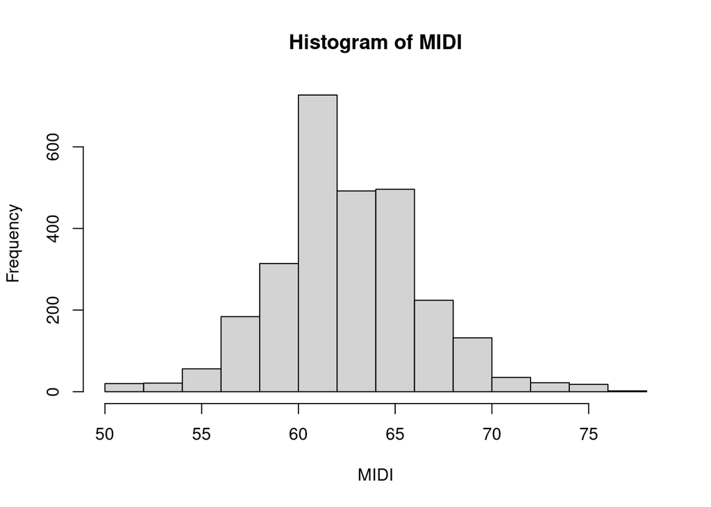

```r
with(LandM, hist(MIDI))
```

```r
with(LandM, table(Chord))
```

```
## Chord
##  A-M   Am   AM  Amm  AMm  B-M B-MM   Bm  BMm  C#m   CM  CMm   Dm   DM  Dmm  DMm
##   16   70  106   43  110  349  107  143   57   51  281   31  270  234  146   98
##  DMM  E-M   Em   EM  Emm  EMm  F#m  F#M   FM  FMm   Gm   GM  Gmm  GMm
##   24  106   26  133   16  197   56   11  203   84   86  491   43   17
```

```r
with(LandM, table(Chord, Tonic))
```

```
##       Tonic
## Chord    0   2   4   5   7   9  10
##   A-M   16   0   0   0   0   0   0
##   Am     0  68   1   1   0   0   0
##   AM     0  31   0   0   0  75   0
##   Amm    0   0   0  43   0   0   0
##   AMm    0   0  90   5   0  15   0
##   B-M   50   0   0   0   0   0 299
##   B-MM   0   0   0 107   0   0   0
##   Bm     0  70   0   0  18  55   0
##   BMm    0   0  57   0   0   0   0
##   C#m    0   0   0   0   0  51   0
##   CM    48   0  16   0 217   0   0
##   CMm    0   0   0  31   0   0   0
##   Dm     0 233   0   0   0   0  37
##   DM     0 155   0   0  64  15   0
##   Dmm    0 138   0   0   8   0   0
##   DMm    0  64   0  29   5   0   0
##   DMM    0  24   0   0   0   0   0
##   E-M   12   0   0   0   0   0  94
##   Em     0   0   0   0  26   0   0
##   EM     0  79   0   0   0  54   0
##   Emm    0  16   0   0   0   0   0
##   EMm    0   0 197   0   0   0   0
##   F#m    0   0   0   0   0  56   0
##   F#M    0   0   0   0   0  11   0
##   FM    33  18   0  68  47   0  37
##   FMm    0   0   0   0   0   0  84
##   Gm     0  71   0   0   0   0  15
##   GM     9 166   0   0 251  65   0
##   Gmm    0   0   0  43   0   0   0
##   GMm    0   0   0  17   0   0   0
```

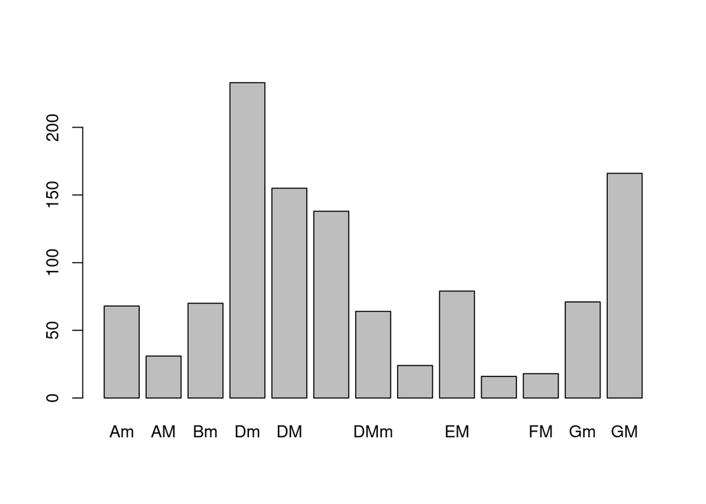

```r
with(subset(LandM, Tonic == 2), table(Chord)) |> barplot()
```

```r
with(LandM, aggregate(MIDI, by = list(Song), mean, na.rm = TRUE))
```

| Group.1 | x |
| --- | --- |
| A Hard Day's Night | 62.63692 |
| Come Together | 63.72141 |
| Eight Days A Week | 63.76744 |
| Help! | 61.78761 |
| I Saw Her Standing There | 63.34409 |
| Love Me Do | 62.05422 |
| Maybe I'm Amazed | 65.96584 |
| My Love | 61.35606 |
| Ob-La-Di, Ob-La-Da | 62.65256 |

```r
within(LandM, tapply(MIDI, Song, \(x) x - mean(x, na.rm = TRUE)) |> unlist() -> SongOffset)
```

| Bar | Duration | MIDI | Tonic | Mode | Chord | Song | Composer | SongOffset |
| --- | --- | --- | --- | --- | --- | --- | --- | --- |
| 2 | 4.0000000 | NA | 2 | Major | DM | Maybe I'm Amazed | Paul | NA |
| 3 | 4.0000000 | NA | 2 | Major | Emm | Maybe I'm Amazed | Paul | NA |
| 4 | 4.0000000 | NA | 2 | Major | AM | Maybe I'm Amazed | Paul | -3.63692308 |
| 5 | 4.0000000 | NA | 2 | Major | AM | Maybe I'm Amazed | Paul | -2.63692308 |
| 6 | 1.0000000 | NA | 0 | Major | B-M | Maybe I'm Amazed | Paul | -3.63692308 |
| 6 | 0.2500000 | 65 | 0 | Major | B-M | Maybe I'm Amazed | Paul | -0.63692308 |
| 6 | 0.2500000 | 65 | 0 | Major | B-M | Maybe I'm Amazed | Paul | -0.63692308 |
| 6 | 0.2500000 | 65 | 0 | Major | B-M | Maybe I'm Amazed | Paul | -0.63692308 |
| 6 | 0.2500000 | 62 | 0 | Major | B-M | Maybe I'm Amazed | Paul | -0.63692308 |
| 6 | 0.5000000 | 65 | 0 | Major | FM | Maybe I'm Amazed | Paul | NA |

[output cut: 3595 more lines]

# Other stuff

## If and Else

In R we can create pretty standard conditional blocks using `if` and `else`:

```r
x <- 714

if (x %% 3 == 0) {
        print("714 is divisible by three")
} else {
        print("714 is not divisibly by three")
}
```

```
## [1] "714 is divisible by three"
```

However, we can also do *vectorized* conditions using `ifelse()`. For example, recall that in our Lennon & McCartney data, rests in the vocal part show up as `NA` in the MIDI column. What if we wanted these `NA` values to be something else?

```r
within(LandM, MIDI <- ifelse(is.na(MIDI), "Rest", MIDI))
```

| Bar | Duration | MIDI | Tonic | Mode | Chord | Song | Composer |
| --- | --- | --- | --- | --- | --- | --- | --- |
| 2 | 4.0000000 | Rest | 2 | Major | DM | Maybe I'm Amazed | Paul |
| 3 | 4.0000000 | Rest | 2 | Major | Emm | Maybe I'm Amazed | Paul |
| 4 | 4.0000000 | Rest | 2 | Major | AM | Maybe I'm Amazed | Paul |
| 5 | 4.0000000 | Rest | 2 | Major | AM | Maybe I'm Amazed | Paul |
| 6 | 1.0000000 | Rest | 0 | Major | B-M | Maybe I'm Amazed | Paul |
| 6 | 0.2500000 | 65 | 0 | Major | B-M | Maybe I'm Amazed | Paul |
| 6 | 0.2500000 | 65 | 0 | Major | B-M | Maybe I'm Amazed | Paul |
| 6 | 0.2500000 | 65 | 0 | Major | B-M | Maybe I'm Amazed | Paul |
| 6 | 0.2500000 | 62 | 0 | Major | B-M | Maybe I'm Amazed | Paul |
| 6 | 0.5000000 | 65 | 0 | Major | FM | Maybe I'm Amazed | Paul |

[output cut: 3595 more lines]

## Defining Functions

In R, you can define new functions using the syntax `\(arguments) expression`. For example,

```r
square <- \(x) x^2

square(12)
```

```
## [1] 144
```

> Write a function that converts MIDI (pitch) numbers to 12-tone pitch classes.

> Write a function that changes compound steps (like 9 or 11) to their simple version (2 and 4)

> Write a function that translates pich class intervals (0-11) to their “classes” (0-6). I.e., 7 -> 5, 11 -> 1, etc. Hint: I would use ifelse for this.

lists

table/tally